# Multi-Class Tabular Model for Steel Plates Faults Using Python and XGBoost

### October 5, 2022

SUMMARY: The project aims to construct a predictive model using various machine learning algorithms and document the end-to-end steps using a template. The Steel Plates Faults dataset is a multi-class modeling situation where we attempt to predict one of several (more than two) possible outcomes.

INTRODUCTION: This dataset comes from research by Semeion, Research Center of Sciences of Communication. The original aim of the research was to correctly classify the type of surface defects in stainless steel plates, with six types of possible defects (plus "other"). The Input vector was made up of 27 indicators that approximately the geometric shape of the defect and its outline. According to the research paper, Semeion was commissioned by the Centro Sviluppo Materiali (Italy) for this task, and therefore it is not possible to provide details on the nature of the 27 indicators used as Input vectors or the types of the six classes of defects.

ANALYSIS: The performance of the preliminary XGBoost model achieved an accuracy benchmark of 78.72%. After a series of tuning trials, the final model processed the training dataset with an accuracy score of 81.29%.

CONCLUSION: In this iteration, the XGBoost model appeared to be a suitable algorithm for modeling this dataset.

Dataset Used: Steel Plates Faults

Dataset ML Model: Multi-Class classification with numerical features

Dataset Reference: https://archive-beta.ics.uci.edu/ml/datasets/steel+plates+faults

One source of potential performance benchmarks: https://www.kaggle.com/uciml/faulty-steel-plates

## Task 1 - Prepare Environment

```python
# Retrieve the GPU information
gpu_info = !nvidia-smi
gpu_info = '\n'.join(gpu_info)
print(gpu_info)
```

```
Fri Sep 30 19:27:18 2022
+-----------------------------------------------------------------------------+
| NVIDIA-SMI 460.32.03    Driver Version: 460.32.03    CUDA Version: 11.2     |
|-------------------------------+----------------------+----------------------+
| GPU  Name        Persistence-M| Bus-Id        Disp.A | Volatile Uncorr. ECC |
| Fan  Temp  Perf  Pwr:Usage/Cap|         Memory-Usage | GPU-Util  Compute M. |
|                               |                      |               MIG M. |
|===============================+======================+======================|
|   0  A100-SXM4-40GB      Off  | 00000000:00:04.0 Off |                    0 |
| N/A   42C    P0    54W / 400W |      0MiB / 40536MiB |      0%      Default |
|                               |                      |             Disabled |
+-------------------------------+----------------------+----------------------+

+-----------------------------------------------------------------------------+
| Processes:                                                                  |
|  GPU   GI   CI        PID   Type   Process name                  GPU Memory |
|        ID   ID                                                   Usage      |
|=============================================================================|
|  No running processes found                                                 |
+-----------------------------------------------------------------------------+
```

```python
# Retrieve the memory configuration
from psutil import virtual_memory
ram_gb = virtual_memory().total / 1e9
print('Your runtime has {:.1f} gigabytes of available RAM\n'.format(ram_gb))
```

```
Your runtime has 89.6 gigabytes of available RAM
```

```python
# Retrieve the CPU information
ncpu = !nproc
print("The number of available CPUs is:", ncpu[0])
```

```
The number of available CPUs is: 12
```

### 1.a) Load libraries and modules

```python
# Set the random seed number for reproducible results
RNG_SEED = 888
```

```python
import numpy as np
import pandas as pd
import seaborn as sns
import matplotlib.pyplot as plt
import os
import sys
import math
# import boto3
import zipfile
import urllib
from datetime import datetime
from sklearn import preprocessing
from sklearn.model_selection import train_test_split
from sklearn.model_selection import StratifiedKFold
from sklearn.model_selection import cross_val_score
from sklearn.model_selection import GridSearchCV
from sklearn.metrics import classification_report
from sklearn.metrics import confusion_matrix
from sklearn.metrics import accuracy_score
from sklearn.pipeline import Pipeline
from sklearn import compose
from sklearn import impute

# from sklearn.feature_selection import RFE
# from imblearn.pipeline import Pipeline
# from imblearn.over_sampling import SMOTE
# from imblearn.under_sampling import RandomUnderSampler

from xgboost import XGBClassifier
```

### 1.b) Set up the controlling parameters and functions

```python
# Begin the timer for the script processing
START_TIME_SCRIPT = datetime.now()

# Set up the number of CPU cores available for multi-thread processing
N_JOBS = 1

# Set up the flag to stop sending progress emails (setting to True will send status emails!)
NOTIFY_STATUS = False

# Set the percentage sizes for splitting the dataset
TEST_SET_RATIO = 0.1
VAL_SET_RATIO = 0.1

# Set the name for the class/label column
ORIGINAL_LABEL = 'Other_Faults'
CLASS_COLUMN = 'target'

# Set the number of folds for cross validation
N_FOLDS = 10

# Set default modeling scoring metric
SCORING_METRIC = 'accuracy'

# Define the directory locations and file names
TRAIN_DATASET = 'Faults.NNA'
```

```python
# Set up the email notification function
def status_notify(msg_text):
    access_key = os.environ.get('SNS_ACCESS_KEY')
    secret_key = os.environ.get('SNS_SECRET_KEY')
    aws_region = os.environ.get('SNS_AWS_REGION')
    topic_arn = os.environ.get('SNS_TOPIC_ARN')
    if (access_key is None) or (secret_key is None) or (aws_region is None):
        sys.exit("Incomplete notification setup info. Script Processing Aborted!!!")
    sns = boto3.client('sns', aws_access_key_id=access_key, aws_secret_access_key=secret_key, region_name=aws_region)
    response = sns.publish(TopicArn=topic_arn, Message=msg_text)
    if response['ResponseMetadata']['HTTPStatusCode'] != 200 :
        print('Status notification not OK with HTTP status code:', response['ResponseMetadata']['HTTPStatusCode'])
```

```python
if NOTIFY_STATUS: status_notify("Task 1 - Prepare Environment has begun! " + datetime.now().strftime('%a %B %d, %Y %I:%M:%S %p'))
```

### 1.c) Load dataset

```python
colNames = []
variable_path = 'https://archive.ics.uci.edu/ml/machine-learning-databases/00198/Faults27x7_var'
variable_list = urllib.request.urlopen(variable_path)
for line in variable_list:
    item = line.decode("utf-8").rstrip("\r\n")
    colNames = colNames + [item]

dataset_path = 'https://archive.ics.uci.edu/ml/machine-learning-databases/00198/Faults.NNA'
df_dataset_import = pd.read_csv(dataset_path, names=colNames, sep='\t', header=None)

# Take a peek at the dataframe after import
print(df_dataset_import.head())
```

```
   X_Minimum  X_Maximum  Y_Minimum  Y_Maximum  Pixels_Areas  X_Perimeter  \
0         42         50     270900     270944           267           17
1        645        651    2538079    2538108           108           10
2        829        835    1553913    1553931            71            8
3        853        860     369370     369415           176           13
4       1289       1306     498078     498335          2409           60

   Y_Perimeter  Sum_of_Luminosity  Minimum_of_Luminosity  \
0           44              24220                     76
1           30              11397                     84
2           19               7972                     99
3           45              18996                     99
4          260             246930                     37

   Maximum_of_Luminosity  ...  Orientation_Index  Luminosity_Index  \
```

[output cut: 21 more lines]

```python
df_dataset_import.info(verbose=True)
```

```
<class 'pandas.core.frame.DataFrame'>
RangeIndex: 1941 entries, 0 to 1940
Data columns (total 34 columns):
 #   Column                 Non-Null Count  Dtype
---  ------                 --------------  -----
 0   X_Minimum              1941 non-null   int64
 1   X_Maximum              1941 non-null   int64
 2   Y_Minimum              1941 non-null   int64
 3   Y_Maximum              1941 non-null   int64
 4   Pixels_Areas           1941 non-null   int64
 5   X_Perimeter            1941 non-null   int64
 6   Y_Perimeter            1941 non-null   int64
 7   Sum_of_Luminosity      1941 non-null   int64
 8   Minimum_of_Luminosity  1941 non-null   int64
 9   Maximum_of_Luminosity  1941 non-null   int64
```

[output cut: 26 more lines]

```python
print(df_dataset_import.describe())
```

```
         X_Minimum    X_Maximum     Y_Minimum     Y_Maximum   Pixels_Areas  \
count  1941.000000  1941.000000  1.941000e+03  1.941000e+03    1941.000000
mean    571.136012   617.964451  1.650685e+06  1.650739e+06    1893.878413
std     520.690671   497.627410  1.774578e+06  1.774590e+06    5168.459560
min       0.000000     4.000000  6.712000e+03  6.724000e+03       2.000000
25%      51.000000   192.000000  4.712530e+05  4.712810e+05      84.000000
50%     435.000000   467.000000  1.204128e+06  1.204136e+06     174.000000
75%    1053.000000  1072.000000  2.183073e+06  2.183084e+06     822.000000
max    1705.000000  1713.000000  1.298766e+07  1.298769e+07  152655.000000

        X_Perimeter   Y_Perimeter  Sum_of_Luminosity  Minimum_of_Luminosity  \
count   1941.000000   1941.000000       1.941000e+03            1941.000000
mean     111.855229     82.965997       2.063121e+05              84.548686
std      301.209187    426.482879       5.122936e+05              32.134276
min        2.000000      1.000000       2.500000e+02               0.000000
25%       15.000000     13.000000       9.522000e+03              63.000000
50%       26.000000     25.000000       1.920200e+04              90.000000
75%       84.000000     83.000000       8.301100e+04             106.000000
max    10449.000000  18152.000000       1.159141e+07             203.000000

       Maximum_of_Luminosity  ...  Orientation_Index  Luminosity_Index  \
count            1941.000000  ...        1941.000000       1941.000000
mean              130.193715  ...           0.083288         -0.131305
std                18.690992  ...           0.500868          0.148767
min                37.000000  ...          -0.991000         -0.998900
25%               124.000000  ...          -0.333300         -0.195000
50%               127.000000  ...           0.095200         -0.133000
75%               140.000000  ...           0.511600         -0.066600
max               253.000000  ...           0.991700          0.642100

       SigmoidOfAreas       Pastry    Z_Scratch     K_Scatch       Stains  \
count     1941.000000  1941.000000  1941.000000  1941.000000  1941.000000
mean         0.585420     0.081401     0.097888     0.201443     0.037094
std          0.339452     0.273521     0.297239     0.401181     0.189042
min          0.119000     0.000000     0.000000     0.000000     0.000000
25%          0.248200     0.000000     0.000000     0.000000     0.000000
50%          0.506300     0.000000     0.000000     0.000000     0.000000
75%          0.999800     0.000000     0.000000     0.000000     0.000000
max          1.000000     1.000000     1.000000     1.000000     1.000000

         Dirtiness        Bumps  Other_Faults
count  1941.000000  1941.000000   1941.000000
mean      0.028336     0.207110      0.346728
std       0.165973     0.405339      0.476051
min       0.000000     0.000000      0.000000
25%       0.000000     0.000000      0.000000
50%       0.000000     0.000000      0.000000
75%       0.000000     0.000000      1.000000
max       1.000000     1.000000      1.000000

[8 rows x 34 columns]
```

```python
print(df_dataset_import.isnull().sum())
print('Total number of NaN in the dataframe: ', df_dataset_import.isnull().sum().sum())
```

```
X_Minimum                0
X_Maximum                0
Y_Minimum                0
Y_Maximum                0
Pixels_Areas             0
X_Perimeter              0
Y_Perimeter              0
Sum_of_Luminosity        0
Minimum_of_Luminosity    0
Maximum_of_Luminosity    0
Length_of_Conveyer       0
TypeOfSteel_A300         0
TypeOfSteel_A400         0
Steel_Plate_Thickness    0
Edges_Index              0
Empty_Index              0
Square_Index             0
Outside_X_Index          0
Edges_X_Index            0
Edges_Y_Index            0
Outside_Global_Index     0
LogOfAreas               0
Log_X_Index              0
Log_Y_Index              0
Orientation_Index        0
Luminosity_Index         0
SigmoidOfAreas           0
Pastry                   0
Z_Scratch                0
K_Scatch                 0
Stains                   0
Dirtiness                0
Bumps                    0
Other_Faults             0
dtype: int64
Total number of NaN in the dataframe:  0
```

```python
# Get grouping size for the target variable
# print(df_dataset_import.groupby(ORIGINAL_LABEL).size())
```

### 1.d) Data Cleaning

```python
# Preprocess and standardize the class column name
y_onehot = df_dataset_import.loc[:,'Pastry':'Other_Faults']
df_dataset_import[CLASS_COLUMN] = y_onehot.idxmax(axis=1)
df_dataset_import.drop(columns=['Pastry','Z_Scratch','K_Scatch','Stains','Dirtiness','Bumps','Other_Faults'], inplace=True)

# Take a peek at the dataframe after cleaning
print(df_dataset_import.head())
```

```
   X_Minimum  X_Maximum  Y_Minimum  Y_Maximum  Pixels_Areas  X_Perimeter  \
0         42         50     270900     270944           267           17
1        645        651    2538079    2538108           108           10
2        829        835    1553913    1553931            71            8
3        853        860     369370     369415           176           13
4       1289       1306     498078     498335          2409           60

   Y_Perimeter  Sum_of_Luminosity  Minimum_of_Luminosity  \
0           44              24220                     76
1           30              11397                     84
2           19               7972                     99
3           45              18996                     99
4          260             246930                     37

   Maximum_of_Luminosity  ...  Edges_X_Index  Edges_Y_Index  \
```

[output cut: 21 more lines]

```python
df_dataset_import.info(verbose=True)
```

```
<class 'pandas.core.frame.DataFrame'>
RangeIndex: 1941 entries, 0 to 1940
Data columns (total 28 columns):
 #   Column                 Non-Null Count  Dtype
---  ------                 --------------  -----
 0   X_Minimum              1941 non-null   int64
 1   X_Maximum              1941 non-null   int64
 2   Y_Minimum              1941 non-null   int64
 3   Y_Maximum              1941 non-null   int64
 4   Pixels_Areas           1941 non-null   int64
 5   X_Perimeter            1941 non-null   int64
 6   Y_Perimeter            1941 non-null   int64
 7   Sum_of_Luminosity      1941 non-null   int64
 8   Minimum_of_Luminosity  1941 non-null   int64
 9   Maximum_of_Luminosity  1941 non-null   int64
```

[output cut: 20 more lines]

```python
print(df_dataset_import.describe())
```

```
         X_Minimum    X_Maximum     Y_Minimum     Y_Maximum   Pixels_Areas  \
count  1941.000000  1941.000000  1.941000e+03  1.941000e+03    1941.000000
mean    571.136012   617.964451  1.650685e+06  1.650739e+06    1893.878413
std     520.690671   497.627410  1.774578e+06  1.774590e+06    5168.459560
min       0.000000     4.000000  6.712000e+03  6.724000e+03       2.000000
25%      51.000000   192.000000  4.712530e+05  4.712810e+05      84.000000
50%     435.000000   467.000000  1.204128e+06  1.204136e+06     174.000000
75%    1053.000000  1072.000000  2.183073e+06  2.183084e+06     822.000000
max    1705.000000  1713.000000  1.298766e+07  1.298769e+07  152655.000000

        X_Perimeter   Y_Perimeter  Sum_of_Luminosity  Minimum_of_Luminosity  \
count   1941.000000   1941.000000       1.941000e+03            1941.000000
mean     111.855229     82.965997       2.063121e+05              84.548686
std      301.209187    426.482879       5.122936e+05              32.134276
min        2.000000      1.000000       2.500000e+02               0.000000
25%       15.000000     13.000000       9.522000e+03              63.000000
50%       26.000000     25.000000       1.920200e+04              90.000000
75%       84.000000     83.000000       8.301100e+04             106.000000
max    10449.000000  18152.000000       1.159141e+07             203.000000

       Maximum_of_Luminosity  ...  Outside_X_Index  Edges_X_Index  \
count            1941.000000  ...      1941.000000    1941.000000
mean              130.193715  ...         0.033361       0.610529
std                18.690992  ...         0.058961       0.243277
min                37.000000  ...         0.001500       0.014400
25%               124.000000  ...         0.006600       0.411800
50%               127.000000  ...         0.010100       0.636400
75%               140.000000  ...         0.023500       0.800000
max               253.000000  ...         0.875900       1.000000

       Edges_Y_Index  Outside_Global_Index   LogOfAreas  Log_X_Index  \
count    1941.000000           1941.000000  1941.000000  1941.000000
mean        0.813472              0.575734     2.492388     1.335686
std         0.234274              0.482352     0.788930     0.481612
min         0.048400              0.000000     0.301000     0.301000
25%         0.596800              0.000000     1.924300     1.000000
50%         0.947400              1.000000     2.240600     1.176100
75%         1.000000              1.000000     2.914900     1.518500
max         1.000000              1.000000     5.183700     3.074100

       Log_Y_Index  Orientation_Index  Luminosity_Index  SigmoidOfAreas
count  1941.000000        1941.000000       1941.000000     1941.000000
mean      1.403271           0.083288         -0.131305        0.585420
std       0.454345           0.500868          0.148767        0.339452
min       0.000000          -0.991000         -0.998900        0.119000
25%       1.079200          -0.333300         -0.195000        0.248200
50%       1.322200           0.095200         -0.133000        0.506300
75%       1.732400           0.511600         -0.066600        0.999800
max       4.258700           0.991700          0.642100        1.000000

[8 rows x 27 columns]
```

```python
print(df_dataset_import.isnull().sum())
print('Total number of NaN in the dataframe: ', df_dataset_import.isnull().sum().sum())
```

```
X_Minimum                0
X_Maximum                0
Y_Minimum                0
Y_Maximum                0
Pixels_Areas             0
X_Perimeter              0
Y_Perimeter              0
Sum_of_Luminosity        0
Minimum_of_Luminosity    0
Maximum_of_Luminosity    0
Length_of_Conveyer       0
TypeOfSteel_A300         0
TypeOfSteel_A400         0
Steel_Plate_Thickness    0
Edges_Index              0
Empty_Index              0
Square_Index             0
Outside_X_Index          0
Edges_X_Index            0
Edges_Y_Index            0
Outside_Global_Index     0
LogOfAreas               0
Log_X_Index              0
Log_Y_Index              0
Orientation_Index        0
Luminosity_Index         0
SigmoidOfAreas           0
target                   0
dtype: int64
Total number of NaN in the dataframe:  0
```

```python
# Get grouping size for the target variable
print(df_dataset_import.groupby(CLASS_COLUMN).size())
```

```
target
Bumps           402
Dirtiness        55
K_Scatch        391
Other_Faults    673
Pastry          158
Stains           72
Z_Scratch       190
dtype: int64
```

### 1.e) Splitting Data into Sets

```python
# Use variable total_column_count to hold the number of columns in the dataframe
total_column_count = len(df_dataset_import.columns)

# Set up variable total_feature_count for the total number of attribute columns
total_feature_count = total_column_count-1

# We create attribute-only and target-only datasets (df_features_train and df_target_train)
df_target_train = df_dataset_import['target']
df_features_train = df_dataset_import.drop(['target'], axis=1)

print("df_dataset_import.shape: {} df_features_train.shape: {} df_target_train.shape: {}".format(df_dataset_import.shape, df_features_train.shape, df_target_train.shape))
```

```
df_dataset_import.shape: (1941, 28) df_features_train.shape: (1941, 27) df_target_train.shape: (1941,)
```

### 1.f) Set up the parameters for data visualization

```python
# Set up the number of row and columns for visualization display. display_rows * display_columns should be >= total_feature_count
display_columns = 4
if total_feature_count % display_columns == 0 :
    display_rows = total_feature_count // display_columns
else :
    display_rows = (total_feature_count // display_columns) + 1

# Set figure width to display the data visualization plots
fig_size = plt.rcParams["figure.figsize"]
fig_size[0] = display_columns * 4
fig_size[1] = display_rows * 4
plt.rcParams["figure.figsize"] = fig_size
```

```python
if NOTIFY_STATUS: status_notify("Task 1 - Prepare Environment completed! " + datetime.now().strftime('%a %B %d, %Y %I:%M:%S %p'))
```

## Task 2 - Summarize and Visualize Data

```python
if NOTIFY_STATUS: status_notify("Task 2 - Summarize and Visualize Data has begun! " + datetime.now().strftime('%a %B %d, %Y %I:%M:%S %p'))
```

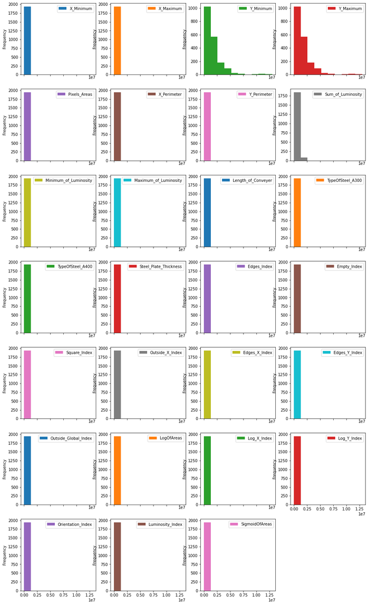

```python
# Histograms for each attribute
df_features_train.plot(kind='hist', subplots=True, layout=(display_rows, display_columns))
plt.show()
```

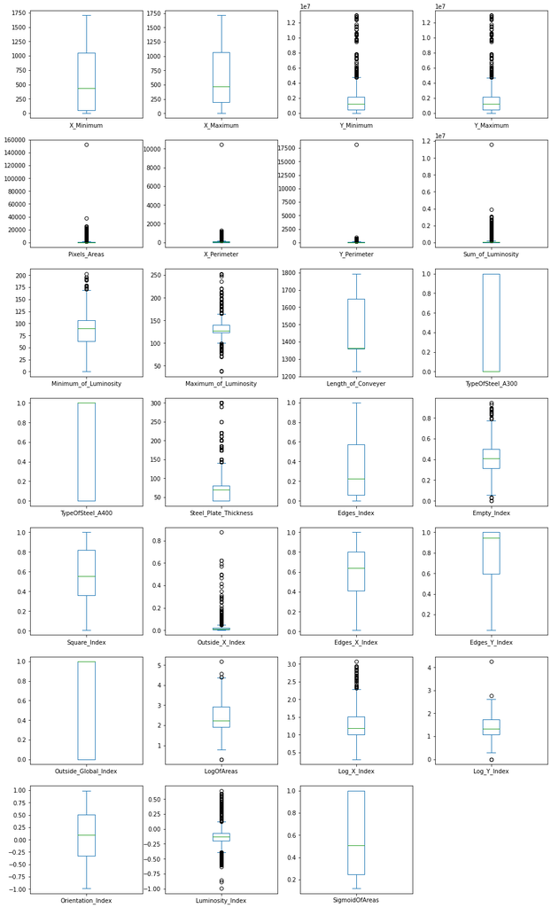

```python
# Box and Whisker plot for each attribute
df_features_train.plot(kind='box', subplots=True, layout=(display_rows, display_columns))
plt.show()
```

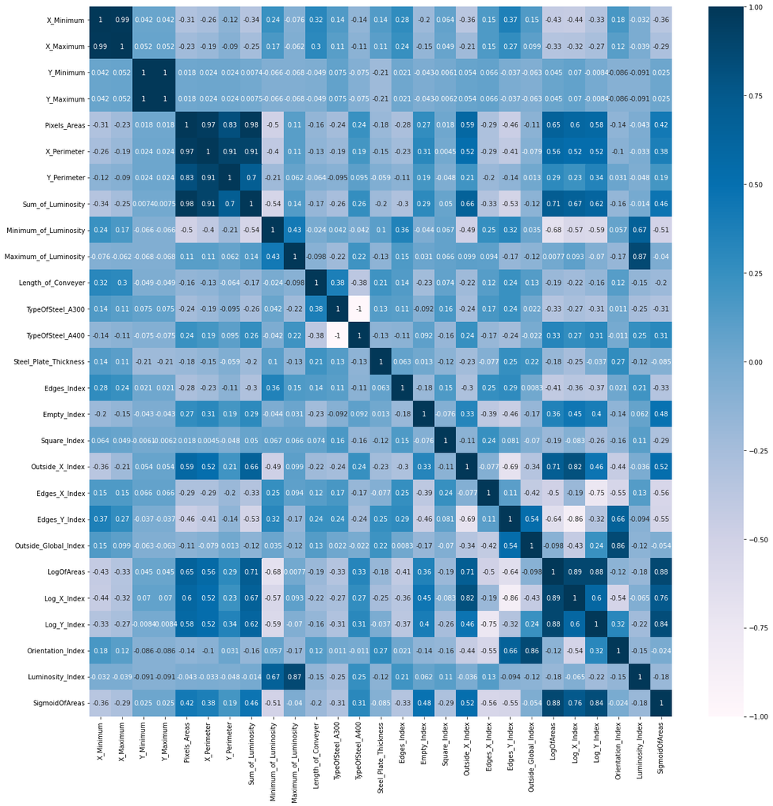

```python
# Correlation matrix
fig = plt.figure(figsize=(20, 20))
correlations = df_features_train.corr(method='pearson')
sns.heatmap(correlations, annot=True, cmap=plt.cm.PuBu)
plt.show()
```

```python
if NOTIFY_STATUS: status_notify("Task 2 - Summarize and Visualize Data completed! " + datetime.now().strftime('%a %B %d, %Y %I:%M:%S %p'))
```

## Task 3 - Pre-process Data

```python
if NOTIFY_STATUS: status_notify("Task 3 - Pre-process Data has begun! " + datetime.now().strftime('%a %B %d, %Y %I:%M:%S %p'))
```

### 3.a) Feature Scaling

```python
# Compose pipeline for the numerical and categorical features (Block #1 of 2)
numeric_columns = df_features_train.select_dtypes(include=['int']).columns
numeric_transformer = Pipeline(steps=[
    ('imputer', impute.SimpleImputer(strategy="constant", fill_value=0)),
    ('scaler', preprocessing.StandardScaler())
])
categorical_columns = df_features_train.select_dtypes(include=['object','bool','category']).columns
categorical_transformer = Pipeline(steps=[
    ('imputer', impute.SimpleImputer(strategy='constant', fill_value='UKNOWN')),
    ('onehot', preprocessing.OneHotEncoder(sparse=False, handle_unknown='ignore'))
])

print("Number of numerical columns:", len(numeric_columns))
print("Number of categorical columns:", len(categorical_columns))
print("Total number of columns in the feature dataframe:", df_features_train.shape[1])
```

```
Number of numerical columns: 14
Number of categorical columns: 0
Total number of columns in the feature dataframe: 27
```

```python
# Compose pipeline for the numerical and categorical features (Block #2 of 2)
preprocessor = compose.ColumnTransformer(transformers=[
    ('num', numeric_transformer, numeric_columns),
    ('cat', categorical_transformer, categorical_columns)
    ], remainder='passthrough')

# Display the shapes of the training dataset for final inspection
array_features_train = preprocessor.fit_transform(df_features_train)
print("Transformed features from df_features_train.shape: {} to array_features_train.shape: {}".format(df_features_train.shape, array_features_train.shape))
```

```
Transformed features from df_features_train.shape: (1941, 27) to array_features_train.shape: (1941, 27)
```

### 3.b) Training Data Balancing

```python
# Not applicable for this iteration of the project
```

### 3.c) Feature Selection

```python
# Not applicable for this iteration of the project
```

### 3.d) Display the Final Datasets for Model-Building

```python
# Finalize the training dataset for the modeling activities
array_features_train = preprocessor.fit_transform(df_features_train)
label_encoder = preprocessing.LabelEncoder()
array_target_train = label_encoder.fit_transform(df_target_train)
print("array_features_train.shape: {} array_target_train.shape: {}".format(array_features_train.shape, array_target_train.shape))
```

```
array_features_train.shape: (1941, 27) array_target_train.shape: (1941,)
```

```python
if NOTIFY_STATUS: status_notify("Task 3 - Pre-process Data completed! " + datetime.now().strftime('%a %B %d, %Y %I:%M:%S %p'))
```

## Task 4 - Train and Tune Models

```python
if NOTIFY_STATUS: status_notify("Task 4 - Train and Tune Models has begun! " + datetime.now().strftime('%a %B %d, %Y %I:%M:%S %p'))
```

### 4.a) Set test options and evaluation metric

```python
# Set up Algorithms Spot-Checking Array
start_time_training = datetime.now()
train_models = []
train_results = []
train_model_names = []
train_metrics = []
```

```python
train_models.append(('XGB', XGBClassifier(random_state=RNG_SEED, n_jobs=N_JOBS, objective='multi:softmax', use_label_encoder=False, eval_metric='mlogloss', tree_method='gpu_hist')))
```

```python
# Generate model in turn
for name, model in train_models:
    if NOTIFY_STATUS: status_notify("Algorithm "+name+" modeling has begun! " + datetime.now().strftime('%a %B %d, %Y %I:%M:%S %p'))
    start_time_module = datetime.now()
    kfold = StratifiedKFold(n_splits=N_FOLDS, shuffle=True, random_state=RNG_SEED)
    cv_results = cross_val_score(model, array_features_train, array_target_train, cv=kfold, scoring=SCORING_METRIC, n_jobs=N_JOBS, verbose=1)
    train_results.append(cv_results)
    train_model_names.append(name)
    train_metrics.append(cv_results.mean())
    print("%s: %f (%f)" % (name, cv_results.mean(), cv_results.std()))
    print(model)
    print ('Model training time:', (datetime.now() - start_time_module), '\n')
    if NOTIFY_STATUS: status_notify("Algorithm "+name+" modeling completed! " + datetime.now().strftime('%a %B %d, %Y %I:%M:%S %p'))
print ('Average metrics (' + SCORING_METRIC + ') from all models:', np.mean(train_metrics))
print ('Total training time for all models:', (datetime.now() - start_time_training))
```

```
[Parallel(n_jobs=1)]: Using backend SequentialBackend with 1 concurrent workers.
```

```
XGB: 0.787219 (0.028265)
XGBClassifier(eval_metric='mlogloss', objective='multi:softmax',
              random_state=888, tree_method='gpu_hist',
              use_label_encoder=False)
Model training time: 0:00:57.296284

Average metrics (accuracy) from all models: 0.7872191382500661
Total training time for all models: 0:00:57.313120
```

```
[Parallel(n_jobs=1)]: Done  10 out of  10 | elapsed:   57.3s finished
```

### 4.b) Algorithm Tuning

```python
# Set up the comparison array
tune_results = []
tune_model_names = []
```

```python
# Tuning XGBoost n_estimators, max_depth, and min_child_weight parameters
start_time_Module = datetime.now()
if NOTIFY_STATUS: status_notify("Algorithm tuning iteration #1 has begun! " + datetime.now().strftime('%a %B %d, %Y %I:%M:%S %p'))

tune_model1 = XGBClassifier(random_state=RNG_SEED, n_jobs=N_JOBS, objective='multi:softprob', use_label_encoder=False, eval_metric='mlogloss', tree_method='gpu_hist')
tune_model_names.append('XGB_1')
paramGrid1 = dict(n_estimators=range(100, 501, 100),
                  max_depth=np.array([3, 6, 9]),
                  min_child_weight=np.array([1, 2, 3]))

kfold = StratifiedKFold(n_splits=N_FOLDS, shuffle=True, random_state=RNG_SEED)
grid1 = GridSearchCV(estimator=tune_model1, param_grid=paramGrid1, scoring=SCORING_METRIC, cv=kfold, n_jobs=N_JOBS, verbose=1)
grid_result1 = grid1.fit(array_features_train, array_target_train)

print("Best: %f using %s" % (grid_result1.best_score_, grid_result1.best_params_))
tune_results.append(grid_result1.cv_results_['mean_test_score'])
means = grid_result1.cv_results_['mean_test_score']
stds = grid_result1.cv_results_['std_test_score']
params = grid_result1.cv_results_['params']
for mean, stdev, param in zip(means, stds, params):
    print("%f (%f) with: %r" % (mean, stdev, param))
print ('Model training time:', (datetime.now() - start_time_Module))
if NOTIFY_STATUS: status_notify("Algorithm tuning iteration #1 completed! " + datetime.now().strftime('%a %B %d, %Y %I:%M:%S %p'))
```

```
Fitting 10 folds for each of 45 candidates, totalling 450 fits
Best: 0.811425 using {'max_depth': 9, 'min_child_weight': 1, 'n_estimators': 300}
0.787219 (0.028265) with: {'max_depth': 3, 'min_child_weight': 1, 'n_estimators': 100}
0.798044 (0.018679) with: {'max_depth': 3, 'min_child_weight': 1, 'n_estimators': 200}
0.802162 (0.023767) with: {'max_depth': 3, 'min_child_weight': 1, 'n_estimators': 300}
0.805250 (0.023750) with: {'max_depth': 3, 'min_child_weight': 1, 'n_estimators': 400}
0.802160 (0.025926) with: {'max_depth': 3, 'min_child_weight': 1, 'n_estimators': 500}
0.789284 (0.027513) with: {'max_depth': 3, 'min_child_weight': 2, 'n_estimators': 100}
0.799075 (0.023031) with: {'max_depth': 3, 'min_child_weight': 2, 'n_estimators': 200}
0.803188 (0.020257) with: {'max_depth': 3, 'min_child_weight': 2, 'n_estimators': 300}
0.799585 (0.022188) with: {'max_depth': 3, 'min_child_weight': 2, 'n_estimators': 400}
0.800098 (0.022839) with: {'max_depth': 3, 'min_child_weight': 2, 'n_estimators': 500}
0.787214 (0.032249) with: {'max_depth': 3, 'min_child_weight': 3, 'n_estimators': 100}
0.798551 (0.023830) with: {'max_depth': 3, 'min_child_weight': 3, 'n_estimators': 200}
0.796497 (0.021522) with: {'max_depth': 3, 'min_child_weight': 3, 'n_estimators': 300}
0.801129 (0.023567) with: {'max_depth': 3, 'min_child_weight': 3, 'n_estimators': 400}
0.801131 (0.024541) with: {'max_depth': 3, 'min_child_weight': 3, 'n_estimators': 500}
0.799588 (0.019485) with: {'max_depth': 6, 'min_child_weight': 1, 'n_estimators': 100}
0.799585 (0.023126) with: {'max_depth': 6, 'min_child_weight': 1, 'n_estimators': 200}
0.801649 (0.028715) with: {'max_depth': 6, 'min_child_weight': 1, 'n_estimators': 300}
0.803193 (0.027745) with: {'max_depth': 6, 'min_child_weight': 1, 'n_estimators': 400}
0.805258 (0.032810) with: {'max_depth': 6, 'min_child_weight': 1, 'n_estimators': 500}
0.806807 (0.013590) with: {'max_depth': 6, 'min_child_weight': 2, 'n_estimators': 100}
0.806286 (0.024193) with: {'max_depth': 6, 'min_child_weight': 2, 'n_estimators': 200}
0.797528 (0.030226) with: {'max_depth': 6, 'min_child_weight': 2, 'n_estimators': 300}
0.795469 (0.027256) with: {'max_depth': 6, 'min_child_weight': 2, 'n_estimators': 400}
0.798559 (0.027594) with: {'max_depth': 6, 'min_child_weight': 2, 'n_estimators': 500}
0.797008 (0.019762) with: {'max_depth': 6, 'min_child_weight': 3, 'n_estimators': 100}
0.803188 (0.027875) with: {'max_depth': 6, 'min_child_weight': 3, 'n_estimators': 200}
0.799577 (0.027486) with: {'max_depth': 6, 'min_child_weight': 3, 'n_estimators': 300}
0.795971 (0.027361) with: {'max_depth': 6, 'min_child_weight': 3, 'n_estimators': 400}
0.794941 (0.027229) with: {'max_depth': 6, 'min_child_weight': 3, 'n_estimators': 500}
0.808332 (0.029849) with: {'max_depth': 9, 'min_child_weight': 1, 'n_estimators': 100}
0.805757 (0.027164) with: {'max_depth': 9, 'min_child_weight': 1, 'n_estimators': 200}
0.811425 (0.030054) with: {'max_depth': 9, 'min_child_weight': 1, 'n_estimators': 300}
0.810912 (0.030117) with: {'max_depth': 9, 'min_child_weight': 1, 'n_estimators': 400}
0.809363 (0.031085) with: {'max_depth': 9, 'min_child_weight': 1, 'n_estimators': 500}
0.808343 (0.019969) with: {'max_depth': 9, 'min_child_weight': 2, 'n_estimators': 100}
0.807309 (0.027436) with: {'max_depth': 9, 'min_child_weight': 2, 'n_estimators': 200}
0.802160 (0.024665) with: {'max_depth': 9, 'min_child_weight': 2, 'n_estimators': 300}
0.802672 (0.025304) with: {'max_depth': 9, 'min_child_weight': 2, 'n_estimators': 400}
0.800613 (0.021916) with: {'max_depth': 9, 'min_child_weight': 2, 'n_estimators': 500}
0.800605 (0.025345) with: {'max_depth': 9, 'min_child_weight': 3, 'n_estimators': 100}
0.799577 (0.021889) with: {'max_depth': 9, 'min_child_weight': 3, 'n_estimators': 200}
0.802146 (0.026209) with: {'max_depth': 9, 'min_child_weight': 3, 'n_estimators': 300}
0.798025 (0.025448) with: {'max_depth': 9, 'min_child_weight': 3, 'n_estimators': 400}
0.797513 (0.025040) with: {'max_depth': 9, 'min_child_weight': 3, 'n_estimators': 500}
Model training time: 0:18:46.125506
```

```python
BEST_MAX_DEPTH = grid_result1.best_params_['max_depth']
BEST_MIN_CHILD_WEIGHT = grid_result1.best_params_['min_child_weight']
BEST_N_ESTIMATORS = grid_result1.best_params_['n_estimators']
print('Best max_depth parameter:', BEST_MAX_DEPTH)
print('Best min_child_weight parameter:', BEST_MIN_CHILD_WEIGHT)
print('Best n_estimators parameter:', BEST_N_ESTIMATORS)
```

```
Best max_depth parameter: 9
Best min_child_weight parameter: 1
Best n_estimators parameter: 300
```

```python
# Tuning XGBoost subsample and colsample_bytree parameters
start_time_Module = datetime.now()
if NOTIFY_STATUS: status_notify("Algorithm tuning iteration #2 has begun! " + datetime.now().strftime('%a %B %d, %Y %I:%M:%S %p'))

tune_model2 = XGBClassifier(n_estimators=BEST_N_ESTIMATORS, max_depth=BEST_MAX_DEPTH, min_child_weight=BEST_MIN_CHILD_WEIGHT,
                            random_state=RNG_SEED, n_jobs=N_JOBS, objective='multi:softprob', use_label_encoder=False, eval_metric='mlogloss', tree_method='gpu_hist')
tune_model_names.append('XGB_2')
paramGrid2 = dict(subsample=np.array([0.7, 0.8, 0.9, 1.0]),
                  colsample_bytree=np.array([0.7, 0.8, 0.9, 1.0]))

kfold = StratifiedKFold(n_splits=N_FOLDS, shuffle=True, random_state=RNG_SEED)
grid2 = GridSearchCV(estimator=tune_model2, param_grid=paramGrid2, scoring=SCORING_METRIC, cv=kfold, n_jobs=N_JOBS, verbose=1)
grid_result2 = grid2.fit(array_features_train, array_target_train)

print("Best: %f using %s" % (grid_result2.best_score_, grid_result2.best_params_))
tune_results.append(grid_result2.cv_results_['mean_test_score'])
means = grid_result2.cv_results_['mean_test_score']
stds = grid_result2.cv_results_['std_test_score']
params = grid_result2.cv_results_['params']
for mean, stdev, param in zip(means, stds, params):
    print("%f (%f) with: %r" % (mean, stdev, param))
print ('Model training time:',(datetime.now() - start_time_Module))
if NOTIFY_STATUS: status_notify("Algorithm tuning iteration #2 completed! " + datetime.now().strftime('%a %B %d, %Y %I:%M:%S %p'))
```

```
Fitting 10 folds for each of 16 candidates, totalling 160 fits
Best: 0.812969 using {'colsample_bytree': 0.9, 'subsample': 1.0}
0.809881 (0.023635) with: {'colsample_bytree': 0.7, 'subsample': 0.7}
0.806270 (0.029533) with: {'colsample_bytree': 0.7, 'subsample': 0.8}
0.810391 (0.027829) with: {'colsample_bytree': 0.7, 'subsample': 0.9}
0.808845 (0.027415) with: {'colsample_bytree': 0.7, 'subsample': 1.0}
0.807824 (0.028836) with: {'colsample_bytree': 0.8, 'subsample': 0.7}
0.809881 (0.024300) with: {'colsample_bytree': 0.8, 'subsample': 0.8}
0.810394 (0.028101) with: {'colsample_bytree': 0.8, 'subsample': 0.9}
0.812450 (0.019037) with: {'colsample_bytree': 0.8, 'subsample': 1.0}
0.809886 (0.027740) with: {'colsample_bytree': 0.9, 'subsample': 0.7}
0.810404 (0.020092) with: {'colsample_bytree': 0.9, 'subsample': 0.8}
0.809358 (0.028241) with: {'colsample_bytree': 0.9, 'subsample': 0.9}
0.812969 (0.022219) with: {'colsample_bytree': 0.9, 'subsample': 1.0}
0.807827 (0.026516) with: {'colsample_bytree': 1.0, 'subsample': 0.7}
0.807309 (0.022662) with: {'colsample_bytree': 1.0, 'subsample': 0.8}
0.807309 (0.024790) with: {'colsample_bytree': 1.0, 'subsample': 0.9}
0.811425 (0.030054) with: {'colsample_bytree': 1.0, 'subsample': 1.0}
Model training time: 0:09:21.206482
```

```python
BEST_COLSAMPLE_BYTREE = grid_result2.best_params_['colsample_bytree']
BEST_SUBSAMPLE = grid_result2.best_params_['subsample']
print('Best colsample_bytree parameter:', BEST_COLSAMPLE_BYTREE)
print('Best subsample parameter:', BEST_SUBSAMPLE)
```

```
Best colsample_bytree parameter: 0.9
Best subsample parameter: 1.0
```

### 4.c) Compare Algorithms After Tuning

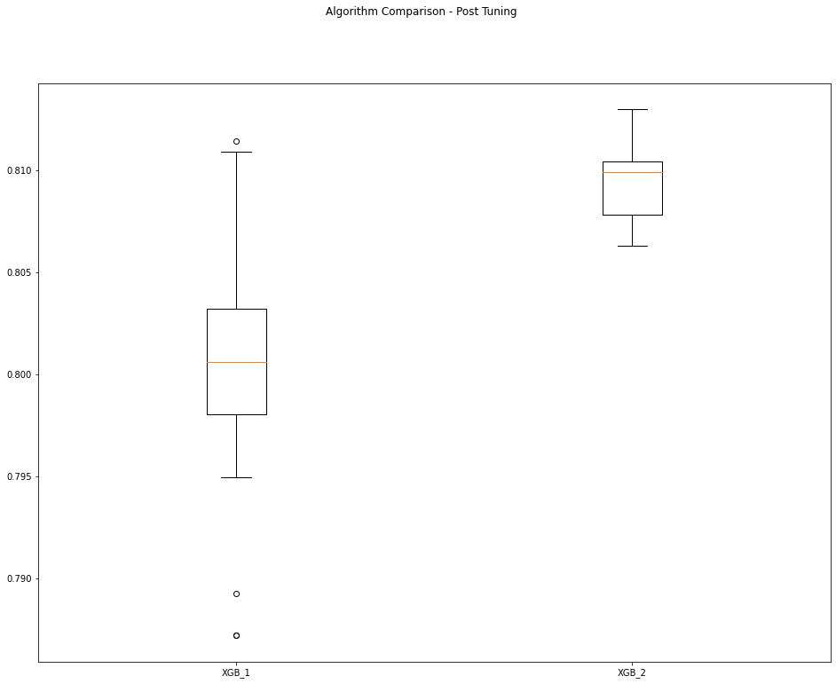

```python
fig = plt.figure(figsize=(16,12))
fig.suptitle('Algorithm Comparison - Post Tuning')
ax = fig.add_subplot(111)
plt.boxplot(tune_results)
ax.set_xticklabels(tune_model_names)
plt.show()
```

```python
if NOTIFY_STATUS: status_notify("Task 4 - Train and Tune Models completed! " + datetime.now().strftime('%a %B %d, %Y %I:%M:%S %p'))
```

## Task 5 - Finalize Model and Make Predictions

```python
if NOTIFY_STATUS: status_notify("Task 5 - Finalize Model and Make Predictions has begun! " + datetime.now().strftime('%a %B %d, %Y %I:%M:%S %p'))
```

```python
final_model = XGBClassifier(n_estimators=BEST_N_ESTIMATORS, max_depth=BEST_MAX_DEPTH, min_child_weight=BEST_MIN_CHILD_WEIGHT,
                            colsample_bytree=BEST_COLSAMPLE_BYTREE, subsample=BEST_SUBSAMPLE, random_state=RNG_SEED,
                            n_jobs=N_JOBS, objective='multi:softprob', use_label_encoder=False, eval_metric='mlogloss', tree_method='gpu_hist')
final_model.fit(array_features_train, array_target_train)
print(final_model)
```

```
XGBClassifier(colsample_bytree=0.9, eval_metric='mlogloss', max_depth=9,
              n_estimators=300, objective='multi:softprob', random_state=888,
              subsample=1.0, tree_method='gpu_hist', use_label_encoder=False)
```

```python
if NOTIFY_STATUS: status_notify("Task 5 - Finalize Model and Make Predictions completed! " + datetime.now().strftime('%a %B %d, %Y %I:%M:%S %p'))
```

```python
print ('Total time for the script:',(datetime.now() - START_TIME_SCRIPT))
```

```
Total time for the script: 0:29:22.176287
```